# Módulo 4. Preparación de datos de contornos: CSV y XLSX

Curso corto: Análisis de contornos de otolitos con R

Luis Cubillos

Noviembre 2026

# Objetivos del módulo

1. Representar una **configuración** y un **conjunto de configuraciones** en R (matriz, vector, arreglo, data.frame).
2. Diseñar una tabla de datos de contornos **ordenada** y reproducible.
3. **Leer y escribir** contornos en **CSV** y **XLSX**.
4. **Validar** los datos antes del análisis.
5. Convertir entre formatos **largo**, **ancho** y **arreglo p × k × n**.

```r
library(readxl)    # read_excel(): leer .xlsx
library(writexl)   # write_xlsx(): escribir .xlsx (sin Java ni Excel instalado)
```

# Configuraciones en R

# Una configuración: matriz p × k

Claude (2008, secc. 2.1.2): *p* filas (puntos) y *k* columnas (dimensiones). El orden de los puntos debe ser **el mismo** en todas las configuraciones.

Ejemplo del curso de 2011: un otolito de 50 pseudolandmarks guardado en CSV.

```r
oto <- as.matrix(read.csv("datos/oto0101.csv", row.names = 1))
colnames(oto) <- c("x", "y")
dim(oto)
```

```
#> [1] 50  2
```

```r
head(oto, 3)
```

```
#>           x        y
#> 1 -370.0929 447.3769
#> 2 -414.0929 388.3769
#> 3 -460.0929 334.3769
```

```r
m <- as.vector(t(oto))      # forma vectorizada: x1, y1, x2, y2, ...
m[1:6]
```

```
#> [1] -370.0929  447.3769 -414.0929  388.3769 -460.0929  334.3769
```

# Varias configuraciones

| Objeto | Dimensiones | Cuándo usarlo |
| --- | --- | --- |
| **arreglo** (`array`) | p × k × n | Funciones de forma: un otolito por capa `A[, , i]` |
| **data.frame ancho** | n × (k·p) | Estadística multivariada: una fila por otolito |
| **lista** | n elementos p × k | Configuraciones con distinto nº de puntos |
| **data.frame largo** | (n·p) × columnas | **Archivos** CSV/XLSX: una fila por punto |

```r
A <- array(NA_real_, dim = c(50, 2, 2))   # 50 puntos, x/y, 2 otolitos
A[, , 1] <- oto
A[, , 2] <- oto * 1.1                      # un segundo otolito (ficticio)
dim(A)
```

```
#> [1] 50  2  2
```

# Formatos de archivo

# Tres maneras de guardar contornos

**1. Apilado sin identificador** (`datos/mcolaz1.txt`): dos columnas x, y; cada otolito ocupa 50 filas seguidas. Compacto, pero frágil: si falta una fila, todos los otolitos siguientes quedan desplazados.

**2. Largo** (*tidy*): **una fila por punto**, con identificador.

| id | zona | punto | x | y |
| --- | --- | --- | --- | --- |
| Ch01 | Ch | 1 | -370.1 | 447.4 |
| Ch01 | Ch | 2 | -414.1 | 388.4 |

**3. Ancho**: **una fila por otolito**, columnas x1…x50, y1…y50.

Recomendación: contornos en formato **largo** + una **tabla de otolitos** (id, zona, talla, sexo, edad, lado, archivo de imagen) relacionadas por `id`.

# Leer los archivos apilados de tres zonas

```r
zonas <- data.frame(zona   = c("Ch", "Ay", "Ma"),
                    nombre = c("Chiloé", "Aysén", "Magallanes"),
                    archivo = sprintf("datos/mcolaz%d.txt", 1:3))
np <- 50
leer_apilado <- function(archivo, zona) {
  d <- read.table(archivo, col.names = c("x", "y"))
  n <- nrow(d) / np
  stopifnot(n == round(n))                        # cada otolito = 50 filas
  data.frame(id    = sprintf("%s%02d", zona, rep(seq_len(n), each = np)),
             zona  = zona,
             punto = rep(seq_len(np), n),
             d)
}
largo <- do.call(rbind, Map(leer_apilado, zonas$archivo, zonas$zona))
rownames(largo) <- NULL
head(largo, 4)
```

```
#>     id zona punto         x          y
#> 1 Ch01   Ch     1 -515.5837  -64.71065
#> 2 Ch01   Ch     2 -456.5837 -116.71065
#> 3 Ch01   Ch     3 -365.5837 -144.71065
#> 4 Ch01   Ch     4 -284.5837 -155.71065
```

```r
dim(largo)
```

```
#> [1] 3350    5
```

# Tabla de otolitos (metadatos)

```r
otolitos <- unique(largo[, c("id", "zona")])
otolitos$nombre_zona <- zonas$nombre[match(otolitos$zona, zonas$zona)]
rownames(otolitos) <- NULL
table(otolitos$nombre_zona)
```

```
#>
#>      Aysén     Chiloé Magallanes
#>         20         26         21
```

```r
head(otolitos, 3)
```

```
#>     id zona nombre_zona
#> 1 Ch01   Ch      Chiloé
#> 2 Ch02   Ch      Chiloé
#> 3 Ch03   Ch      Chiloé
```

En un estudio real esta tabla tendría además: longitud total del pez, sexo, edad, lado del otolito, fecha, archivo de imagen y escala (píxeles por mm).

Use **códigos** (Ch, Ay, Ma) y no colores ni formatos de celda para identificar grupos: R no lee colores de Excel.

# Escribir y leer CSV

# Escribir CSV

```r
write.csv(largo,    "datos/contornos_3zonas.csv", row.names = FALSE)
write.csv(otolitos, "datos/otolitos_3zonas.csv",  row.names = FALSE)
```

- `write.csv()`: separador **coma**, decimal **punto** (estándar internacional).
- `write.csv2()`: separador **punto y coma**, decimal **coma** (Excel en español).
- `row.names = FALSE` evita una columna extra sin nombre.

```r
write.csv2(largo, "datos/contornos_3zonas_excel_es.csv", row.names = FALSE)
```

# Leer CSV

```r
largo2 <- read.csv("datos/contornos_3zonas.csv")
str(largo2)
```

```
#> 'data.frame':    3350 obs. of  5 variables:
#>  $ id   : chr  "Ch01" "Ch01" "Ch01" "Ch01" ...
#>  $ zona : chr  "Ch" "Ch" "Ch" "Ch" ...
#>  $ punto: int  1 2 3 4 5 6 7 8 9 10 ...
#>  $ x    : num  -516 -457 -366 -285 -226 ...
#>  $ y    : num  -64.7 -116.7 -144.7 -155.7 -163.7 ...
```

Para un CSV con decimal coma: `read.csv2()`, o `read.csv(..., dec = ",", sep = ";")`.

Abrir y guardar un CSV en Excel puede cambiar decimales, separadores y fechas. Mantenga una copia **original sin editar** de los datos crudos.

# Escribir y leer XLSX

# Escribir XLSX con varias hojas

```r
write_xlsx(list(contornos = largo, otolitos = otolitos, zonas = zonas[, 1:2]),
           "datos/contornos_3zonas.xlsx")
```

# Leer XLSX

```r
excel_sheets("datos/contornos_3zonas.xlsx")
```

```
#> [1] "contornos" "otolitos"  "zonas"
```

```r
cx <- read_excel("datos/contornos_3zonas.xlsx", sheet = "contornos")
ot <- read_excel("datos/contornos_3zonas.xlsx", sheet = "otolitos")
class(cx)
```

```
#> [1] "tbl_df"     "tbl"        "data.frame"
```

```r
cx <- as.data.frame(cx)          # tibble -> data.frame
head(cx, 3)
```

```
#>     id zona punto         x          y
#> 1 Ch01   Ch     1 -515.5837  -64.71065
#> 2 Ch01   Ch     2 -456.5837 -116.71065
#> 3 Ch01   Ch     3 -365.5837 -144.71065
```

Argumentos útiles de `read_excel()`: `sheet`, `range = "A1:E101"`, `skip`, `na = c("", "NA")`.

# Validar los datos

# Controles mínimos

```r
validar_contornos <- function(d, np = 50) {
  pts <- table(d$id)
  c(otolitos          = length(pts),
    con_np_puntos     = sum(pts == np),
    NA_en_xy          = sum(is.na(d$x) | is.na(d$y)),
    puntos_duplicados = sum(duplicated(d[, c("id", "punto")])),
    orden_correcto    = all(unlist(tapply(d$punto, d$id, function(p) all(p == seq_len(np))))))
}
validar_contornos(cx)
```

```
#>          otolitos     con_np_puntos          NA_en_xy puntos_duplicados
#>                67                67                 0                 0
#>    orden_correcto
#>                 1
```

```r
all(unique(cx$id) %in% ot$id)     # ¿todos los contornos tienen metadatos?
```

```
#> [1] TRUE
```

# Revisión visual

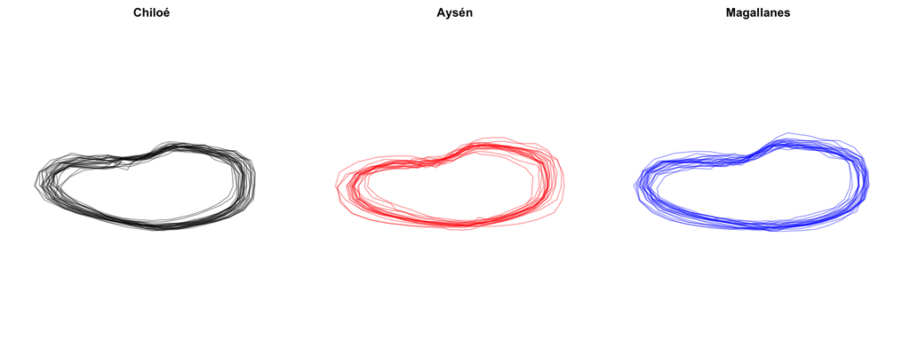

```r
col_z <- c(Ch = "black", Ay = "red", Ma = "blue")
par(mfrow = c(1, 3), mar = c(1, 1, 2, 1))
for (z in zonas$zona) {
  dz <- cx[cx$zona == z, ]
  plot(NA, xlim = c(-700, 700), ylim = c(-350, 350), asp = 1, axes = FALSE,
       xlab = "", ylab = "", main = zonas$nombre[zonas$zona == z])
  for (i in unique(dz$id)) {
    di <- dz[dz$id == i, ]
    polygon(di$x - mean(di$x), di$y - mean(di$y), border = adjustcolor(col_z[z], 0.4))
  }
}
```

Contornos centrados: permite detectar otolitos rotos, invertidos o mal orientados.

# Convertir entre formatos

# Largo → arreglo p × k × n

Es el formato que usarán las funciones de Fourier (módulo 5).

```r
largo_a_array <- function(d, np = 50) {
  ids <- unique(d$id)
  A <- array(NA_real_, dim = c(np, 2, length(ids)), dimnames = list(NULL, c("x", "y"), ids))
  for (i in ids) {
    di <- d[d$id == i, ]
    A[, , i] <- as.matrix(di[order(di$punto), c("x", "y")])
  }
  A
}
A <- largo_a_array(cx)
dim(A)
```

```
#> [1] 50  2 67
```

```r
A[1:3, , "Ay05"]
```

```
#>              x          y
#> [1,] -540.7279  -68.36261
#> [2,] -482.7279 -123.36261
#> [3,] -383.7279 -152.36261
```

# Largo ↔︎ ancho

```r
ancho <- reshape(cx[, c("id", "zona", "punto", "x", "y")], idvar = c("id", "zona"),
                 timevar = "punto", direction = "wide", sep = "")
dim(ancho)                     # 67 otolitos x (2 + 100 columnas)
```

```
#> [1]  67 102
```

```r
names(ancho)[1:6]
```

```
#> [1] "id"   "zona" "x1"   "y1"   "x2"   "y2"
```

```r
de_vuelta <- reshape(ancho, direction = "long", idvar = c("id", "zona"),
                     varying = list(paste0("x", 1:np), paste0("y", 1:np)),
                     v.names = c("x", "y"), timevar = "punto")
de_vuelta <- de_vuelta[order(de_vuelta$id, de_vuelta$punto), ]
all.equal(de_vuelta$x, cx$x[order(cx$id, cx$punto)])
```

```
#> [1] TRUE
```

# Guardar objetos de R y otros formatos

Claude (2008, secc. 2.4):

- `saveRDS(A, "datos/arreglo_3zonas.rds")` / `readRDS()`: un objeto, formato binario de R (conserva dimensiones y nombres).
- `save(A, cx, file = "datos.RData")` / `load()`: varios objetos con su nombre.
- **NTS** y **TPS** (programas de Rohlf: tpsDig, tpsRelw): formatos de texto muy usados en morfometría geométrica; se leen con `scan()` y un poco de manipulación de texto (Claude 2008, pp. 56–58).

```r
saveRDS(A, "datos/arreglo_3zonas.rds")
```

# Buenas prácticas

- Nombres de archivo **sistemáticos** (`Zona1_oto001.pgm`): permiten procesar lotes con bucles (Claude 2008, p. 28).
- **Una fila por observación**, una columna por variable, una tabla por tipo de unidad.
- Datos crudos **de solo lectura**; todo cambio se hace con código.
- Codificación **UTF-8**; evitar tildes y espacios en nombres de columnas.
- Documentar unidades (píxeles o mm), escala y umbral usados.

# Resumen y ejercicio

`mcolaz*.txt` (apilado) → **largo** (id, zona, punto, x, y) → **CSV / XLSX** → validar → **arreglo 50 × 2 × n** para el análisis de forma

**Ejercicio**

1. Agregue a la tabla `otolitos` una columna `LT` (talla) con valores ficticios y guárdela como hoja nueva del XLSX.
2. Agregue el contorno de `datos/otolito_scom_50puntos.csv` (módulo 3) con `id = "Sc01"` y `zona = "Sc"`. ¿Pasa la validación?
3. Escriba el formato **ancho** a CSV y léalo de nuevo con `read.csv()`.